# Exercise 8

Group J: Lindsey Pekurney and Reed Scott

21 March 2022

```r
#----------Global options---------#
#Setting Paths
path.root <- "D:/OneDrive - University of Vermont/Classes/Spring2022/sdhmR/sdhmR-V2022.1" #Reed Laptop Path
#path.root <- "C:/Users/14842/Documents/SDHM/sdhmR-V2022.1" #Lindsey Path
path.ex <- paste(path.root,
                 "/data/exercise/traindat",
                 sep = "") #Path to mod 2
path.preds <- paste(path.root,
                    '/data/exercise/preds',
                    sep = '')
path.figs <- paste(path.root,
                   "/powerpoints/figures",
                   sep = "") #path to save figs
path.gis <- paste(path.root,
                  "/data/gis_layers",
                  sep = "") #path to gis files

# some libraries
library(raster) # FXNS: extent, raster, res, rasterize, values, writeRaster,
#       cellFromXY, extract
library(sf)     # FXNS: st_as_sf, st_as_sfc, st_bbox, st_convex_hull, st_union
#       st_buffer, st_read, st_write, st_intersection, st_geometry,
#       st_drop_geometry, st_coordinates, st_sf
library(terra)  # FXNS: as.data.frame, rast, vect
library(sp)
library(dplyr)
library(tidyverse)
library(data.table)
library(modeest)
 library(PresenceAbsence)
  library(DAAG)
  library(car)
  library(gam)
  options( warn = -1 )
# source course CRSs
setwd(path.root)
getwd()
```

```
## [1] "D:/OneDrive - University of Vermont/Classes/Spring2022/sdhmR/sdhmR-V2022.1"
```

```r
source("r_code/prjs4_sdhmR.r")
ls(pattern = "prj.") # should be 5 prj.* objects
```

```
## [1] "prj.aeaN83"    "prj.gmerc"     "prj.latlong"   "prj.utmWGSz12"
## [5] "prj.wgs84"
```

## This exercise links to Module 5.2

Submit the completed exercise to us at:

- t.edwards@usu.edu
- eric_tsakiris@fws.gov

## Context

The data are of the *Pinus edulis* Common piñon, the species you dealt with in Exercise #3 – #5. This exercise relies on the dataframe you generated in exercise #6. Hopefully you saved those combined presence:absence dataframe, with the reduced variables you begin SDHM model construction with, or regrettably you will need to return to exercise #6 and re–build that dataframe.

The goal is to: * Variables in final model, significance, and direction of relationship * List which variables are “smoothed” vs, those that are not * Plots of the “smoothed” variables * Calculate an estimate of model fit * Build a table of accuracy metrics, and AUC plot * Provide some bulleted interpretation points * Plot map products of the: * (i) probability; and * (ii) classified distribution model * (Save these two maps as **`.img`** files for use later in the course)

Remember, you will have been assigned data for *edulis* having one the following four discrete labels:

- **Seedlings**: these data indicate spatial locations where seedlings of the tree have been found
- **Mortality**: these data indicate spatial locations where mortality has been observed
- **Persistence**: these data have no observed mortality or seedling at given spatial locations
- **Range**: the total dataset, including all spatial locations of seedlings, mortality, and persistence

## The Data

- The dataframe completed in exercise #6.

## Question #1

- Import and explore data
  - **NOTE**: intent is not to reduce number of variables; that was completed in exercise #5. Rather, calculate simple descriptive statistics (mean, sd, n) and boxplots

```r
############################
#Question 1: Import and explore the data
setwd(path.ex)
load('tr_PERS.Rdata')
class(tr_PERS)
```

```
## [1] "data.frame"
```

```r
head(tr_PERS)
```

```
##   FNETID PERS106 wgs_xF wgs_yF exp5nrm exp3nrm rough_1k prad_sw_di etpt_5
## 1    194       0     NA     NA      NA      NA       NA         NA     NA
## 2   1922       0     NA     NA      NA      NA       NA         NA     NA
## 3   3813       0     NA     NA      NA      NA       NA         NA     NA
## 4   5186       0     NA     NA      NA      NA       NA         NA     NA
## 5   5594       0     NA     NA      NA      NA       NA         NA     NA
## 6   6226       0     NA     NA      NA      NA       NA         NA     NA
##   mind_yr_av prec_winte tave_sprin UNIQUEID.x cell.wgs_x cell.wgs_y UNIQUEID.y
## 1         NA         NA         NA       <NA>  -112.9988   42.14331       <NA>
## 2         NA         NA         NA       <NA>  -110.6498   42.13498       <NA>
## 3         NA         NA         NA       <NA>  -106.9429   42.12665       <NA>
## 4         NA         NA         NA       <NA>  -107.5510   42.11832       <NA>
## 5         NA         NA         NA       <NA>  -104.1524   42.11832       <NA>
## 6         NA         NA         NA       <NA>  -110.9330   42.10999       <NA>
##    tr.wgs_x tr.wgs_y etpt_5.img etpt_6.img etpt_sprin.img mind_yr_av.img
## 1 -112.9988 42.14331         NA         NA             NA             NA
## 2 -110.6498 42.13498         81         95       27.00000       -866.750
## 3 -106.9429 42.12665         90         99       51.66667      -1162.417
## 4 -107.5510 42.11832         88         98       49.00000      -1144.833
## 5 -104.1524 42.11832         92        101       68.33334      -1299.583
## 6 -110.9330 42.10999         87         97       47.33333      -1092.000
##   prec_winte.img tave_s_hal.img tave_sprin.img tmax_s_hal.img tmax_summe.img
## 1             NA             NA             NA             NA             NA
## 2       26.33333        93.0000      -1.333333       185.0000       225.0000
## 3       17.00000       135.5000      38.333332       213.1667       256.3333
## 4       13.66667       127.3333      31.333334       209.6667       253.0000
## 5        8.00000       163.5000      75.000000       257.6667       299.0000
## 6       21.00000       115.3333      24.000000       211.3333       251.3333
```

```r
drops <- c('wgs_xF',
           'wgs_yF',
           'cell.wgs_x',
           'cell.wgs_y',
           'exp5nrm',
           'exp3nrm',
           'rough_1k',
           'prad_sw_di',
           'etpt_5',
           'mind_yr_av',
           'prec_winte',
           'tave_sprin',
           'UNIQUEID.x',
           'UNIQUEID.y')
tr_PERS <- tr_PERS[ ,!(names(tr_PERS) %in% drops)]
tr_PERS <- na.omit(tr_PERS)
dim(tr_PERS)
```

```
## [1] 1942   13
```

```r
#attempt to use for() loop
descSTAT <- {}
descSTAT <- as.data.frame(descSTAT)
for(i in 13:length(tr_PERS)){
  mean <- mean(tr_PERS[,i],
               na.rm = T) #mean returned NA
  NAS <- sum(is.na(tr_PERS[,i])) #checked for number of NAs
  SD <- sd(tr_PERS[,i],
           na.rm = T) #standard deviation
  N <- nrow(tr_PERS) - sum(is.na(tr_PERS[,i])) #check total N
  rname <- names(tr_PERS[,i])
  stats <- c(rname,
             mean,
             NAS,
             SD,
             N)
  descSTAT <- rbind(descSTAT,
                    stats)
}

#explore etpt5
mean(tr_PERS$etpt_5.img,
     na.rm = T) #mean returned NA
```

```
## [1] 92.35839
```

```r
sum(is.na(tr_PERS$etpt_5.img)) #checked for number of NAs
```

```
## [1] 0
```

```r
sd(tr_PERS$etpt_5.img,
   na.rm = T) #standard deviation
```

```
## [1] 5.560058
```

```r
nrow(tr_PERS) - sum(is.na(tr_PERS$etpt_5.img)) #check total N
```

```
## [1] 1942
```

```r
#explore etpt6
mean(tr_PERS$etpt_6.img,
     na.rm = T) #mean returned NA
```

```
## [1] 100.0278
```

```r
sum(is.na(tr_PERS$etpt_6.img)) #checked for number of NAs
```

```
## [1] 0
```

```r
sd(tr_PERS$etpt_6.img,
   na.rm = T) #standard deviation
```

```
## [1] 2.18426
```

```r
nrow(tr_PERS) - sum(is.na(tr_PERS$etpt_6.img)) #check total N
```

```
## [1] 1942
```

```r
#explore etpt_sprin
mean(tr_PERS$etpt_sprin.img, na.rm = T) #mean returned NA
```

```
## [1] 69.36011
```

```r
sum(is.na(tr_PERS$etpt_sprin.img)) #checked for number of NAs
```

```
## [1] 0
```

```r
sd(tr_PERS$etpt_sprin.img, na.rm = T) #standard deviation
```

```
## [1] 14.20613
```

```r
nrow(tr_PERS) - sum(is.na(tr_PERS$etpt_sprin.img)) #check total N
```

```
## [1] 1942
```

```r
#explore mind_yr_ave
mean(tr_PERS$mind_yr_av.img, na.rm = T) #mean returned NA
```

```
## [1] -1441.124
```

```r
sum(is.na(tr_PERS$mind_yr_av.img)) #checked for number of NAs
```

```
## [1] 0
```

```r
sd(tr_PERS$mind_yr_av.img, na.rm = T) #standard deviation
```

```
## [1] 334.7886
```

```r
nrow(tr_PERS) - sum(is.na(tr_PERS$mind_yr_av.img)) #check total N
```

```
## [1] 1942
```

```r
#explore prec_winte
mean(tr_PERS$prec_winte.img, na.rm = T) #mean returned NA
```

```
## [1] 23.29059
```

```r
sum(is.na(tr_PERS$prec_winte.img)) #checked for number of NAs
```

```
## [1] 0
```

```r
sd(tr_PERS$prec_winte.img, na.rm = T) #standard deviation
```

```
## [1] 12.59748
```

```r
nrow(tr_PERS) - sum(is.na(tr_PERS$prec_winte.img)) #check total N
```

```
## [1] 1942
```

```r
#explore tave_s_hal
mean(tr_PERS$tave_s_hal.img, na.rm = T) #mean returned NA
```

```
## [1] 169.3242
```

```r
sum(is.na(tr_PERS$tave_s_hal.img)) #checked for number of NAs
```

```
## [1] 0
```

```r
sd(tr_PERS$tave_s_hal.img, na.rm = T) #standard deviation
```

```
## [1] 42.62714
```

```r
nrow(tr_PERS) - sum(is.na(tr_PERS$tave_s_hal.img)) #check total N
```

```
## [1] 1942
```

```r
#explore tave_sprin
mean(tr_PERS$tave_sprin.img, na.rm = T) #mean returned NA
```

```
## [1] 86.88345
```

```r
sum(is.na(tr_PERS$tave_sprin.img)) #checked for number of NAs
```

```
## [1] 0
```

```r
sd(tr_PERS$tave_sprin.img, na.rm = T) #standard deviation
```

```
## [1] 47.30311
```

```r
nrow(tr_PERS) - sum(is.na(tr_PERS$tave_sprin.img)) #check total N
```

```
## [1] 1942
```

```r
#explore tmax_summe
mean(tr_PERS$tmax_summe.img, na.rm = T) #mean returned NA
```

```
## [1] 290.372
```

```r
sum(is.na(tr_PERS$tmax_summe.img)) #checked for number of NAs
```

```
## [1] 0
```

```r
sd(tr_PERS$tmax_summe.img, na.rm = T) #standard deviation
```

```
## [1] 40.88223
```

```r
nrow(tr_PERS) - sum(is.na(tr_PERS$tmax_summe.img)) #check total N
```

```
## [1] 1942
```

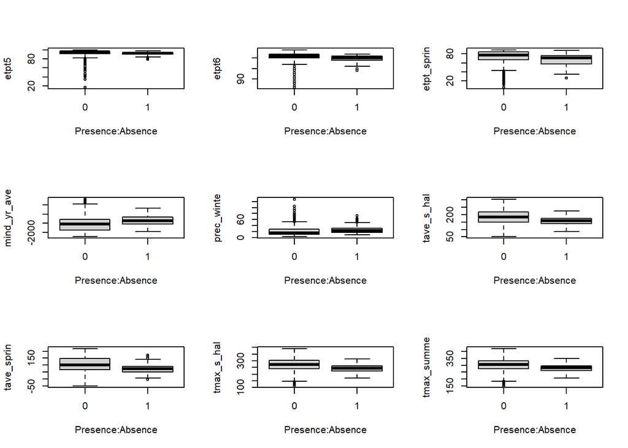

```r
#Boxplots
par(mfrow = c(3, 3))
boxplot(tr_PERS$etpt_5.img ~ tr_PERS$PERS106, xlab = "Presence:Absence",
        ylab = "etpt5", na.rm = T)
boxplot(tr_PERS$etpt_6.img ~ tr_PERS$PERS106, xlab = "Presence:Absence",
        ylab = "etpt6", na.rm = T)
boxplot(tr_PERS$etpt_sprin.img ~ tr_PERS$PERS106, xlab = "Presence:Absence",
        ylab = "etpt_sprin", na.rm = T)
boxplot(tr_PERS$mind_yr_av.img ~ tr_PERS$PERS106, xlab = "Presence:Absence",
        ylab = "mind_yr_ave", na.rm = T)
boxplot(tr_PERS$prec_winte.img ~ tr_PERS$PERS106, xlab = "Presence:Absence",
        ylab = "prec_winte", na.rm = T)
boxplot(tr_PERS$tave_s_hal.img ~ tr_PERS$PERS106, xlab = "Presence:Absence",
        ylab = "tave_s_hal", na.rm = T)
boxplot(tr_PERS$tave_sprin.img ~ tr_PERS$PERS106, xlab = "Presence:Absence",
        ylab = "tave_sprin", na.rm = T)
boxplot(tr_PERS$tmax_s_hal.img ~ tr_PERS$PERS106, xlab = "Presence:Absence",
        ylab = "tmax_s_hal", na.rm = T)
boxplot(tr_PERS$tmax_summe.img ~ tr_PERS$PERS106, xlab = "Presence:Absence",
        ylab = "tmax_summe", na.rm = T)
```

## Question #2

- Construct some basic plots to assess possible relationships warranting use of a GAM
- List which variables may be amenable to a GAM–based smoother

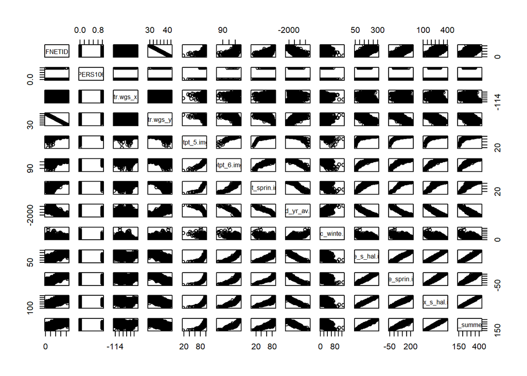

```r
plot(tr_PERS[1:13]) # simple data scatterplots
```

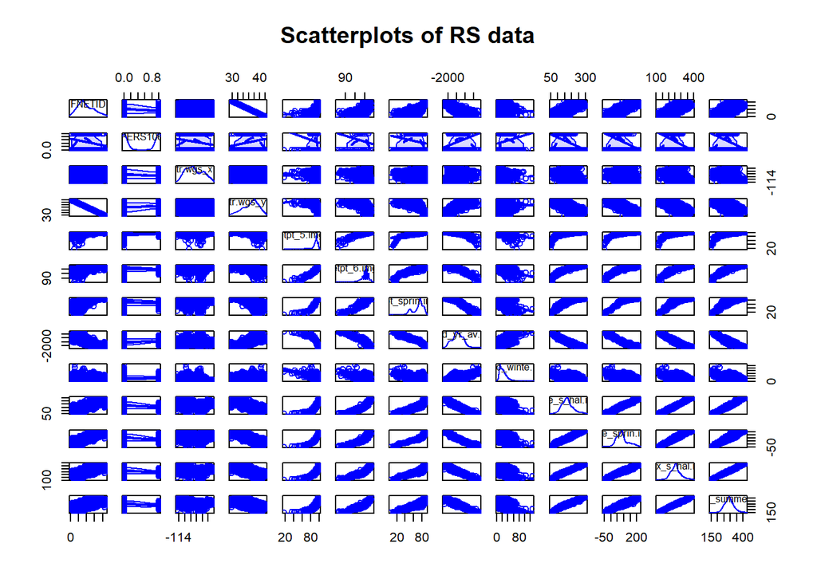

```r
# fancy scatterplot w/lines if desired from library(car)
  scatterplotMatrix(tr_PERS[1:13],
                    main = "Scatterplots of RS data")  # scatterplot
```

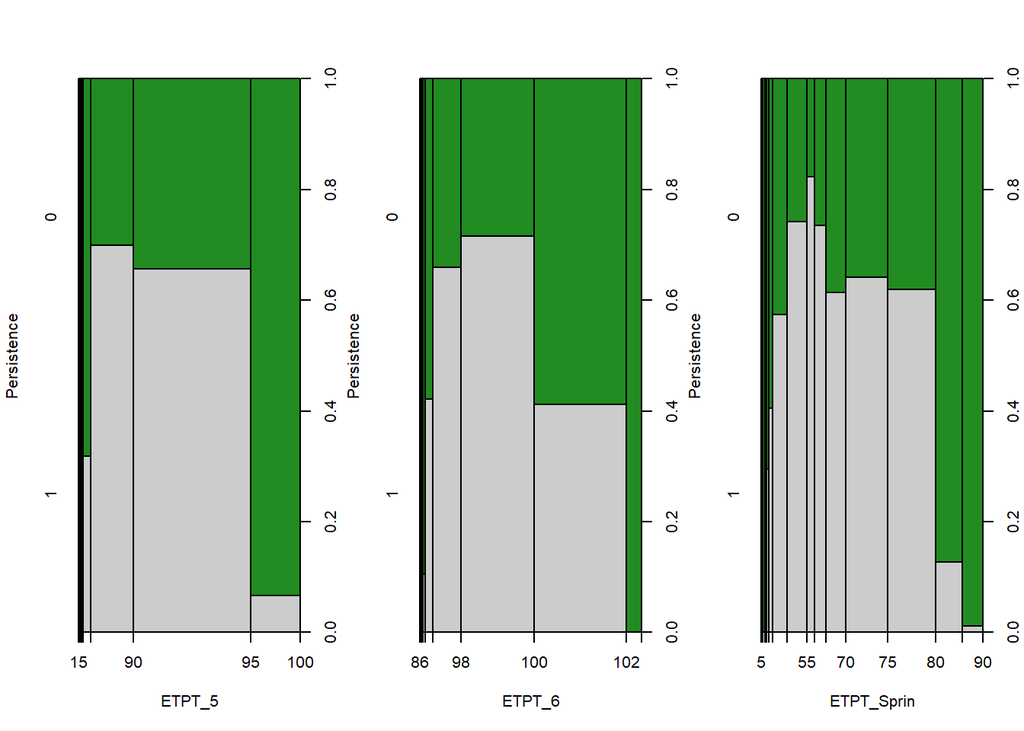

```r
# factor plots
  par(mfcol = c(1, 3)) # if desired
  col.list <- c("grey80",
                "forestgreen") # specified color ramp

  plot(as.factor(tr_PERS$PERS106) ~ tr_PERS$etpt_5.img,
       xlab = "ETPT_5",
       ylab = "Persistence",
    col = col.list)

  plot(as.factor(tr_PERS$PERS106) ~ tr_PERS$etpt_6.img,
       xlab = "ETPT_6",
    ylab = "Persistence",
    col = col.list)

  plot(as.factor(tr_PERS$PERS106) ~ tr_PERS$etpt_sprin.img,
       xlab = "ETPT_Sprin",
       ylab = "Persistence",
    col = col.list)
```

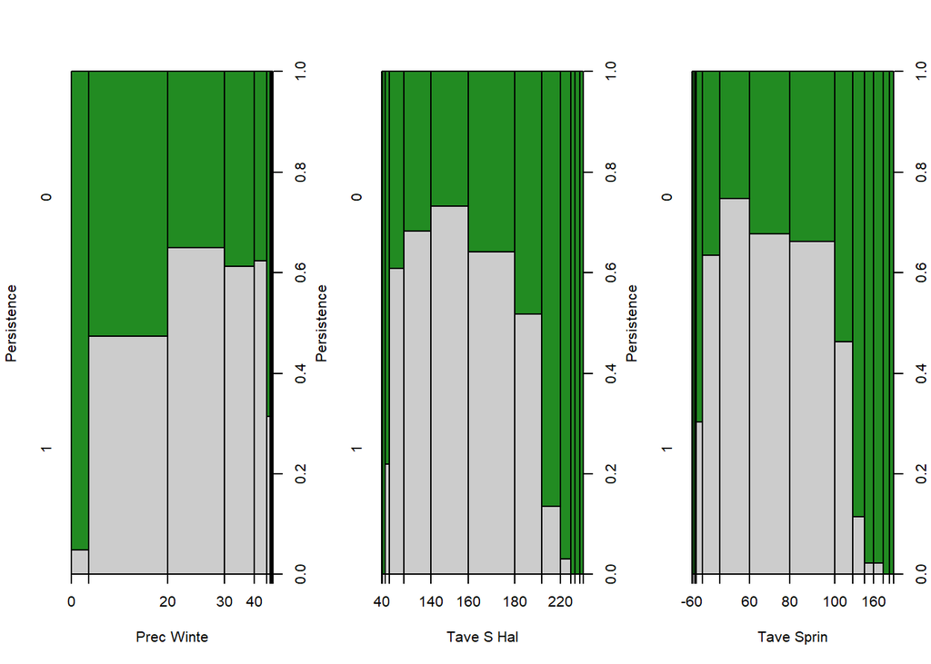

```r
   plot(as.factor(tr_PERS$PERS106) ~ tr_PERS$prec_winte.img,
       xlab = "Prec Winte",
       ylab = "Persistence",
    col = col.list)

    plot(as.factor(tr_PERS$PERS106) ~ tr_PERS$tave_s_hal.img,
       xlab = "Tave S Hal",
       ylab = "Persistence",
    col = col.list)

    plot(as.factor(tr_PERS$PERS106) ~ tr_PERS$tave_sprin.img,
       xlab = "Tave Sprin",
       ylab = "Persistence",
    col = col.list)
```

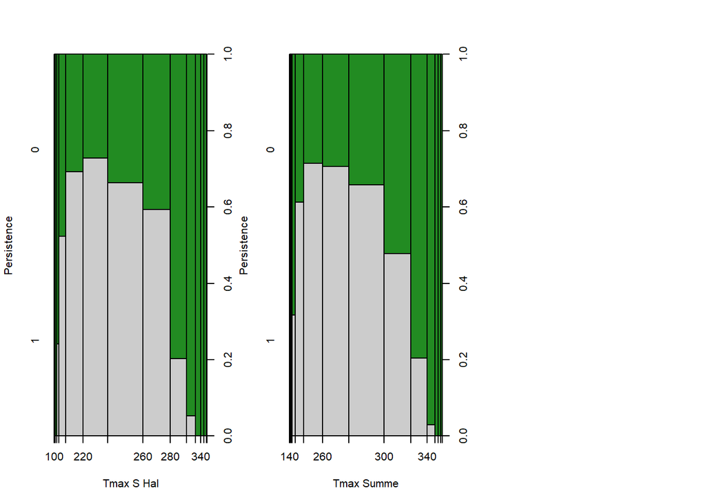

```r
    plot(as.factor(tr_PERS$PERS106) ~ tr_PERS$tmax_s_hal.img,
       xlab = "Tmax S Hal",
       ylab = "Persistence",
    col = col.list)

    plot(as.factor(tr_PERS$PERS106) ~ tr_PERS$tmax_summe.img,
       xlab = "Tmax Summe",
       ylab = "Persistence",
    col = col.list)
```

## Question #3

```r
################################################################################
######## START COMPARATIVE GAM MODELLING

# GAM model 0: all linear
#   can use glm for linear model
  mod0.GLM <- glm(PERS106 ~ etpt_5.img +
                    etpt_6.img +
                    etpt_sprin.img +
                    mind_yr_av.img +
                    prec_winte.img +
                    tave_s_hal.img +
                    tave_sprin.img +
                    tmax_s_hal.img +
                    tmax_summe.img,
    family = binomial,
    data = tr_PERS)

# alternative linear model using gam call
  mod0.GAM <- gam(PERS106 ~ etpt_5.img +
                    etpt_6.img +
                    etpt_sprin.img +
                    mind_yr_av.img +
                    prec_winte.img +
                    tave_s_hal.img +
                    tave_sprin.img +
                    tmax_s_hal.img +
                    tmax_summe.img,
    family = binomial,
    data = tr_PERS,
    )
  summary(mod0.GAM) # model #0 summary
```

```
##
## Call: gam(formula = PERS106 ~ etpt_5.img + etpt_6.img + etpt_sprin.img +
##     mind_yr_av.img + prec_winte.img + tave_s_hal.img + tave_sprin.img +
##     tmax_s_hal.img + tmax_summe.img, family = binomial, data = tr_PERS)
## Deviance Residuals:
##     Min      1Q  Median      3Q     Max
## -2.4889 -0.8704  0.3993  0.8476  2.9300
##
## (Dispersion Parameter for binomial family taken to be 1)
##
##     Null Deviance: 2691.72 on 1941 degrees of freedom
## Residual Deviance: 1945.052 on 1932 degrees of freedom
## AIC: 1965.052
##
## Number of Local Scoring Iterations: 6
##
## Anova for Parametric Effects
##                  Df  Sum Sq Mean Sq  F value    Pr(>F)
## etpt_5.img        1    8.12   8.123   8.4996  0.003593 **
## etpt_6.img        1    1.70   1.700   1.7791  0.182422
## etpt_sprin.img    1    1.14   1.144   1.1968  0.274097
## mind_yr_av.img    1   35.14  35.139  36.7666 1.597e-09 ***
## prec_winte.img    1    5.24   5.237   5.4796  0.019341 *
## tave_s_hal.img    1   80.54  80.541  84.2722 < 2.2e-16 ***
## tave_sprin.img    1  159.21 159.208 166.5843 < 2.2e-16 ***
## tmax_s_hal.img    1   32.76  32.762  34.2795 5.596e-09 ***
## tmax_summe.img    1    7.24   7.236   7.5713  0.005986 **
## Residuals      1932 1846.45   0.956
## ---
## Signif. codes:  0 '***' 0.001 '**' 0.01 '*' 0.05 '.' 0.1 ' ' 1
```

```r
# GAM model 1: all smoothers using defaults df (smoothers=4)
  mod1.GAM <- gam(PERS106 ~ s(etpt_5.img) +
                    s(etpt_6.img) +
                    s(etpt_sprin.img) +
                    s(mind_yr_av.img) +
                    s(prec_winte.img) +
                    s(tave_s_hal.img) +
                    s(tave_sprin.img) +
                    s(tmax_s_hal.img) +
                    s(tmax_summe.img),
    family = binomial,
    data = tr_PERS)
  summary(mod1.GAM) # model #1 summary
```

```
##
## Call: gam(formula = PERS106 ~ s(etpt_5.img) + s(etpt_6.img) + s(etpt_sprin.img) +
##     s(mind_yr_av.img) + s(prec_winte.img) + s(tave_s_hal.img) +
##     s(tave_sprin.img) + s(tmax_s_hal.img) + s(tmax_summe.img),
##     family = binomial, data = tr_PERS)
## Deviance Residuals:
##     Min      1Q  Median      3Q     Max
## -2.5476 -0.6083  0.3552  0.7680  3.6101
##
## (Dispersion Parameter for binomial family taken to be 1)
##
##     Null Deviance: 2691.72 on 1941 degrees of freedom
## Residual Deviance: 1655.622 on 1905 degrees of freedom
## AIC: 1729.621
##
## Number of Local Scoring Iterations: NA
##
## Anova for Parametric Effects
##                     Df  Sum Sq Mean Sq F value    Pr(>F)
## s(etpt_5.img)        1   12.82  12.824 10.8540  0.001004 **
## s(etpt_6.img)        1   17.79  17.787 15.0546  0.000108 ***
## s(etpt_sprin.img)    1   25.51  25.511 21.5921 3.603e-06 ***
## s(mind_yr_av.img)    1   26.63  26.631 22.5404 2.211e-06 ***
## s(prec_winte.img)    1   93.18  93.183 78.8682 < 2.2e-16 ***
## s(tave_s_hal.img)    1    0.71   0.710  0.6006  0.438450
## s(tave_sprin.img)    1    0.27   0.275  0.2326  0.629623
## s(tmax_s_hal.img)    1   62.51  62.512 52.9090 5.080e-13 ***
## s(tmax_summe.img)    1    1.80   1.799  1.5223  0.217423
## Residuals         1905 2250.75   1.181
## ---
## Signif. codes:  0 '***' 0.001 '**' 0.01 '*' 0.05 '.' 0.1 ' ' 1
##
## Anova for Nonparametric Effects
##                   Npar Df Npar Chisq    P(Chi)
## (Intercept)
## s(etpt_5.img)           3      7.830  0.049649 *
## s(etpt_6.img)           3     13.115  0.004394 **
## s(etpt_sprin.img)       3     29.593 1.681e-06 ***
## s(mind_yr_av.img)       3     27.594 4.419e-06 ***
## s(prec_winte.img)       3    103.262 < 2.2e-16 ***
## s(tave_s_hal.img)       3      4.144  0.246318
## s(tave_sprin.img)       3     41.939 4.132e-09 ***
## s(tmax_s_hal.img)       3      4.846  0.183395
## s(tmax_summe.img)       3      1.247  0.741653
## ---
## Signif. codes:  0 '***' 0.001 '**' 0.01 '*' 0.05 '.' 0.1 ' ' 1
```

```r
# GAM model 2: all smoothers using specified df (smoothers=5)
  mod2.GAM <- gam(PERS106 ~ s(etpt_5.img, 5) +
                    s(etpt_6.img, 5) +
                    s(etpt_sprin.img, 5) +
                    s(mind_yr_av.img, 5) +
                    s(prec_winte.img, 5) +
                    s(tave_s_hal.img, 5) +
                    s(tave_sprin.img, 5) +
                    s(tmax_s_hal.img, 5) +
                    s(tmax_summe.img, 5),
                  family = binomial,
                  data = tr_PERS)
  summary(mod2.GAM) # model #2 summary
```

```
##
## Call: gam(formula = PERS106 ~ s(etpt_5.img, 5) + s(etpt_6.img, 5) +
##     s(etpt_sprin.img, 5) + s(mind_yr_av.img, 5) + s(prec_winte.img,
##     5) + s(tave_s_hal.img, 5) + s(tave_sprin.img, 5) + s(tmax_s_hal.img,
##     5) + s(tmax_summe.img, 5), family = binomial, data = tr_PERS)
## Deviance Residuals:
##     Min      1Q  Median      3Q     Max
## -2.5339 -0.5683  0.3459  0.7479  3.6379
##
## (Dispersion Parameter for binomial family taken to be 1)
##
##     Null Deviance: 2691.72 on 1941 degrees of freedom
## Residual Deviance: 1624.126 on 1896 degrees of freedom
## AIC: 1716.125
##
## Number of Local Scoring Iterations: NA
##
## Anova for Parametric Effects
##                        Df  Sum Sq Mean Sq F value    Pr(>F)
## s(etpt_5.img, 5)        1   10.80  10.802  8.8724  0.002932 **
## s(etpt_6.img, 5)        1   19.99  19.985 16.4155 5.292e-05 ***
## s(etpt_sprin.img, 5)    1   36.96  36.961 30.3593 4.080e-08 ***
## s(mind_yr_av.img, 5)    1   38.16  38.157 31.3418 2.479e-08 ***
## s(prec_winte.img, 5)    1  103.74 103.735 85.2068 < 2.2e-16 ***
## s(tave_s_hal.img, 5)    1    0.17   0.165  0.1355  0.712790
## s(tave_sprin.img, 5)    1    4.08   4.081  3.3518  0.067286 .
## s(tmax_s_hal.img, 5)    1   65.29  65.295 53.6324 3.556e-13 ***
## s(tmax_summe.img, 5)    1    3.40   3.399  2.7921  0.094893 .
## Residuals            1896 2308.29   1.217
## ---
## Signif. codes:  0 '***' 0.001 '**' 0.01 '*' 0.05 '.' 0.1 ' ' 1
##
## Anova for Nonparametric Effects
##                      Npar Df Npar Chisq    P(Chi)
## (Intercept)
## s(etpt_5.img, 5)           4      6.115  0.190714
## s(etpt_6.img, 5)           4     16.263  0.002685 **
## s(etpt_sprin.img, 5)       4     39.014 6.920e-08 ***
## s(mind_yr_av.img, 5)       4     33.436 9.726e-07 ***
## s(prec_winte.img, 5)       4    107.419 < 2.2e-16 ***
## s(tave_s_hal.img, 5)       4     10.159  0.037834 *
## s(tave_sprin.img, 5)       4     46.966 1.550e-09 ***
## s(tmax_s_hal.img, 5)       4      8.407  0.077761 .
## s(tmax_summe.img, 5)       4      3.701  0.447980
## ---
## Signif. codes:  0 '***' 0.001 '**' 0.01 '*' 0.05 '.' 0.1 ' ' 1
```

```r
# GAM model 3: stepwise w/diff scopes
  mod3.GAM <- step.Gam(mod2.GAM,
                       scope = list("etpt_5.img" = ~1 +
                                    etpt_5.img +
                                    s(etpt_5.img, 3) +
                                    s(etpt_5.img, 5),
                                  "etpt_6.img" = ~1 +
                                    etpt_6.img +
                                    s(etpt_6.img, 3) +
                                    s(etpt_6.img, 5),
                                  "etpt_sprin.img" = ~1 +
                                    etpt_sprin.img +
                                    s(etpt_sprin.img, 3) +
                                    s(etpt_sprin.img, 5),
                                  "mind_yr_av.img" = ~1 +
                                    mind_yr_av.img +
                                    s(mind_yr_av.img, 3) +
                                    s(mind_yr_av.img, 5),
                                  "prec_winte.img" = ~ 1 +
                                    prec_winte.img +
                                    s(prec_winte.img, 3) +
                                    s(prec_winte.img, 5),
                                  "tave_s_hal.img" = ~1 +
                                    tave_s_hal.img +
                                    s(tave_s_hal.img, 3) +
                                    s(tave_s_hal.img, 5),
                                  "tave_sprin.img" = ~1 +
                                    tave_sprin.img +
                                    s(tave_sprin.img, 3) +
                                    s(tave_sprin.img, 5),
                                  "tmax_s_hal.img" = ~1 +
                                    tmax_s_hal.img +
                                    s(tmax_s_hal.img, 3) +
                                    s(tmax_s_hal.img, 5),
                                  "tmax_summe.img" = ~1 +
                                    tmax_summe.img +
                                    s(tmax_summe.img, 3) +
                                    s(tmax_summe.img, 5)),
                                  trace = F)
  summary(mod3.GAM) # model #3 summary
```

```
##
## Call: gam(formula = PERS106 ~ etpt_5.img + s(etpt_6.img, 3) + s(etpt_sprin.img,
##     5) + s(mind_yr_av.img, 5) + s(prec_winte.img, 5) + tave_s_hal.img +
##     s(tave_sprin.img, 5) + tmax_summe.img, family = binomial,
##     data = tr_PERS, trace = FALSE)
## Deviance Residuals:
##     Min      1Q  Median      3Q     Max
## -2.5778 -0.5728  0.3342  0.7594  3.6906
##
## (Dispersion Parameter for binomial family taken to be 1)
##
##     Null Deviance: 2691.72 on 1941 degrees of freedom
## Residual Deviance: 1642.163 on 1915 degrees of freedom
## AIC: 1696.164
##
## Number of Local Scoring Iterations: NA
##
## Anova for Parametric Effects
##                        Df  Sum Sq Mean Sq F value    Pr(>F)
## etpt_5.img              1   11.06  11.061  8.3967 0.0038018 **
## s(etpt_6.img, 3)        1   18.84  18.836 14.2998 0.0001607 ***
## s(etpt_sprin.img, 5)    1   32.54  32.542 24.7048 7.277e-07 ***
## s(mind_yr_av.img, 5)    1   35.33  35.332 26.8228 2.464e-07 ***
## s(prec_winte.img, 5)    1  103.52 103.520 78.5875 < 2.2e-16 ***
## tave_s_hal.img          1    0.21   0.211  0.1599 0.6892776
## s(tave_sprin.img, 5)    1    2.90   2.904  2.2049 0.1377401
## tmax_summe.img          1   67.64  67.641 51.3504 1.098e-12 ***
## Residuals            1915 2522.54   1.317
## ---
## Signif. codes:  0 '***' 0.001 '**' 0.01 '*' 0.05 '.' 0.1 ' ' 1
##
## Anova for Nonparametric Effects
##                      Npar Df Npar Chisq    P(Chi)
## (Intercept)
## etpt_5.img
## s(etpt_6.img, 3)           2      5.345   0.06909 .
## s(etpt_sprin.img, 5)       4     46.353 2.079e-09 ***
## s(mind_yr_av.img, 5)       4     35.626 3.454e-07 ***
## s(prec_winte.img, 5)       4    109.237 < 2.2e-16 ***
## tave_s_hal.img
## s(tave_sprin.img, 5)       4     45.216 3.585e-09 ***
## tmax_summe.img
## ---
## Signif. codes:  0 '***' 0.001 '**' 0.01 '*' 0.05 '.' 0.1 ' ' 1
```

```r
  names(mod3.GAM$coefficients) # find the linear terms
```

```
## [1] "(Intercept)"          "etpt_5.img"           "s(etpt_6.img, 3)"
## [4] "s(etpt_sprin.img, 5)" "s(mind_yr_av.img, 5)" "s(prec_winte.img, 5)"
## [7] "tave_s_hal.img"       "s(tave_sprin.img, 5)" "tmax_summe.img"
```

```r
  #summary.glm(mod3.GAM)$coefficients[c(1:2, 4:6, 10:11), ] # access linear terms
######## END MODEL COMPARATIVE GAM MODELLING
################################################################################
```

## Question #4

- Calculate accuracy metrics (as in Module 3.2 and 3.3, Analytical Intermission) using:
  - Resubstitution approaches, and
  - A 10-fold cross–validation approach

```r
######## START MODEL COMPARISONS
# estimate model fits
  mod0.glm <- 100 * (1 - mod0.GLM$deviance/mod0.GLM$null.deviance) # model fit
  mod0.fit <- 100 * (1 - mod0.GAM$deviance/mod0.GAM$null.deviance) # model fit
  mod1.fit <- 100 * (1 - mod1.GAM$deviance/mod1.GAM$null.deviance) # model fit
  mod2.fit <- 100 * (1 - mod2.GAM$deviance/mod2.GAM$null.deviance) # model fit
  mod3.fit <- 100 * (1 - mod3.GAM$deviance/mod3.GAM$null.deviance) # model fit
  mods.fit <- cbind(mod0.glm, mod0.fit, mod1.fit, mod2.fit, mod3.fit) # all model fits
  mods.fit # examine
```

```
##      mod0.glm mod0.fit mod1.fit mod2.fit mod3.fit
## [1,] 27.73946 27.73946 38.49206 39.66217 38.99205
```

```r
# measures of resubstitution accuracy
  library(PresenceAbsence) # load pkg for accuracy
  mod.list <- c("mod0.GAM",
                "mod1.GAM",
                "mod2.GAM",
                "mod3.GAM")
  for (i in 1:length(mod.list)) {
    pred <- predict(get(mod.list[i]),
                    type = "response") # predict by model
    mod.num <- mod.list[i] # assign model No. to varname
    dat <- cbind(mod.num,
                 tr_PERS[2],
                 pred) # build obs and prediction dataframe
    cut <- optimal.thresholds(dat,
                              opt.methods = c("PredPrev=Obs")) # threshold=prevalence
    cfmat <- table(dat[[2]],
                   factor(as.numeric(dat$pred >= cut$pred))) # confusion matrix
    acc <- presence.absence.accuracy(dat,
                                     threshold = cut$pred,
                                     st.dev = F) # calc accuracies
    tss <- acc$sensitivity + acc$specificity - 1 # code TSS metric
    acc <- cbind(acc[1:7], tss) # bind all metrics
    acc$model <- mod.num # variable substitution
    if (i == 1) mods.acc <- acc else mods.acc <- rbind(mods.acc, acc) # build output dataframe
    }
  mods.acc[c(1, 4:5, 7:8)] # resubstittution accuracies by model
```

```
##      model sensitivity specificity       AUC       tss
## 1 mod0.GAM   0.7484787   0.7290795 0.8186621 0.4775582
## 2 mod1.GAM   0.7839757   0.7824268 0.8684926 0.5664024
## 3 mod2.GAM   0.7890467   0.7876569 0.8737948 0.5767036
## 4 mod3.GAM   0.7809331   0.7887029 0.8707448 0.5696360
```

```r
# measures of 5-fold cross-validation accuracy
#   absent set.seed() answers will differ among runs
  library(DAAG) # load pkg for crossval
  set.seed(1234) # set seed for replicability
  mod.list <- c("mod0.GAM",
                "mod1.GAM",
                "mod2.GAM",
                "mod3.GAM")
  for (i in 1:length(mod.list)) {
    cv.mod <- CVbinary(get(mod.list[i]),
                       nfolds = 10,
                       print.details = F) # crossval predict
    cv.pers <- cv.mod$cvhat # assign new name to jackknife estimates
    mod.num <- mod.list[i] # assign model No. to varname
    cv.dat <- cbind(mod.num,
                    tr_PERS[2],
                    cv.pers) # build obs and prediction dataframe
    cv.cut <- optimal.thresholds(cv.dat,
                                 opt.methods = c("ObsPrev")) # threshold=pers
    cv.cfmat <- table(cv.dat[[2]],
                      factor(as.numeric(cv.dat$cv.pers > cv.cut$cv.pers))) # confusion matrix
    cv.acc <- presence.absence.accuracy(cv.dat,
                                        threshold = cv.cut$cv.pers,
                                        st.dev = F) # calculate accuracies
    cv.tss <- cv.acc$sensitivity + cv.acc$specificity - 1 # code TSS metric
    cv.acc <- cbind(cv.acc[1:7],
                    cv.tss) # bind all metrics
    cv.acc$model <- mod.num # variable substitution
    if (i == 1) mods.cvacc <- cv.acc else mods.cvacc <- rbind(mods.cvacc, cv.acc) # build output dataframe
    }
  mods.cvacc[c(1, 4:5, 7:8)]  # accuracies by model
```

```
##      model sensitivity specificity       AUC    cv.tss
## 1 mod0.GAM   0.8194726   0.6558577 0.8126533 0.4753304
## 2 mod1.GAM   0.8204868   0.6579498 0.8132633 0.4784366
## 3 mod2.GAM   0.8194726   0.6506276 0.8134532 0.4701002
## 4 mod3.GAM   0.8123732   0.6579498 0.8104499 0.4703230
```

```r
######## END MODEL COMPARISONS
```

## Question #5

- Build 2 prediction maps:
  - A raw probability estimate for each cell in the modelling domain; and
  - A classified map based on the selected threshold from Question #4

```r
setwd(path.preds)
pers.list <- list.files(pattern = ".img$") # list of .img files; $ strips extra
pers.list # examine
```

```
##  [1] "etpt_5.img"     "etpt_6.img"     "etpt_sprin.img" "exp1nrm.img"
##  [5] "exp3nrm.img"    "exp5nrm.img"    "mind_yr_av.img" "prad_sw_di.img"
##  [9] "prec_w_hal.img" "prec_winte.img" "rough_1k.img"   "tave_s_hal.img"
## [13] "tave_sprin.img" "tmax_s_hal.img" "tmax_summe.img" "topos.img"
```

```r
pers.dom <- stack(pers.list) # build raster stack
pers.dom # examine stack
```

```
## class      : RasterStack
## dimensions : 1518, 1478, 2243604, 16  (nrow, ncol, ncell, nlayers)
## resolution : 0.008333333, 0.008333333  (x, y)
## extent     : -114.6167, -102.3, 29.49167, 42.14167  (xmin, xmax, ymin, ymax)
## crs        : +proj=longlat +datum=WGS84 +no_defs
## names      :       etpt_5,       etpt_6,   etpt_sprin,      exp1nrm,      exp3nrm,      exp5nrm,   mind_yr_av,   prad_sw_di,   prec_w_hal,   prec_winte,     rough_1k,   tave_s_hal,   tave_sprin,   tmax_s_hal,   tmax_summe, ...
## min values :     0.000000,    69.000000,     0.000000, -1152.000000,  -812.000000,  -715.000000, -2294.333252,  6411.166016,     3.666667,     3.333333,     0.000000,    16.166666,   -86.000000,    63.833332,   100.000000, ...
## max values :    100.00000,    104.00000,     90.33334,   1246.00000,    945.00000,    895.00000,    249.33333,  14441.50000,    136.83333,    140.33333,    243.85391,    308.33334,    226.66667,    392.33334,    424.00000, ...
```

```r
names(pers.dom) # examine stack names
```

```
##  [1] "etpt_5"     "etpt_6"     "etpt_sprin" "exp1nrm"    "exp3nrm"
##  [6] "exp5nrm"    "mind_yr_av" "prad_sw_di" "prec_w_hal" "prec_winte"
## [11] "rough_1k"   "tave_s_hal" "tave_sprin" "tmax_s_hal" "tmax_summe"
## [16] "topos"
```

```r
names(pers.dom) <- paste(names(pers.dom),'img')

setwd(path.gis)
states <- st_read(dsn = ".",
                  layer = "na_states_wgs") # import shapefile
#create a probability model
pers.prob <- predict(pers.dom,
                     mod1.GAM,
                     type = "response",
                     fun = predict,
                     index = 2,
                     overwrite = T) # prediction raster
pers.prob # examine
```

```
## class      : RasterLayer
## dimensions : 1518, 1478, 2243604  (nrow, ncol, ncell)
## resolution : 0.008333333, 0.008333333  (x, y)
## extent     : -114.6167, -102.3, 29.49167, 42.14167  (xmin, xmax, ymin, ymax)
## crs        : +proj=longlat +datum=WGS84 +no_defs
## source     : memory
## names      : layer
## values     : 2.220446e-16, 0.9871084  (min, max)
```

```r
# next reclassify based on threshold mod.cut per above
pers.class <- reclassify(pers.prob,
                         c(0,cut[[2]],0,
                           cut[[2]],1,1),
                         overwrite=TRUE)
pers.class
```

```
## class      : RasterLayer
## dimensions : 1518, 1478, 2243604  (nrow, ncol, ncell)
## resolution : 0.008333333, 0.008333333  (x, y)
## extent     : -114.6167, -102.3, 29.49167, 42.14167  (xmin, xmax, ymin, ymax)
## crs        : +proj=longlat +datum=WGS84 +no_defs
## source     : memory
## names      : layer
## values     : 0, 1  (min, max)
```

```r
#restrict class and prob models to domain
setwd(path.ex)
load('pers.PPsA.RData')
pers.bufR <-raster(pers.bufR)
new.pers.bufR <- projectRaster(pers.bufR,
                               pers.class)
pers.class <- pers.class*new.pers.bufR
```

[output not shown]

```r
pers.prob <- pers.prob*new.pers.bufR
```

[output not shown]

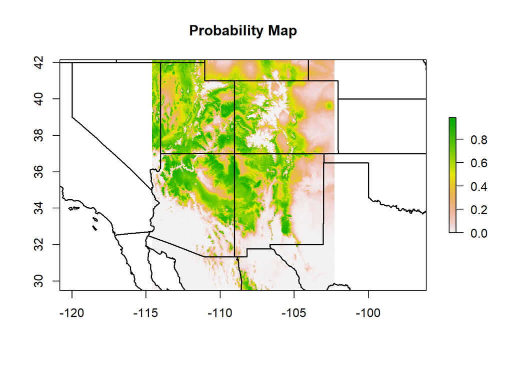

```r
#Plot probability map#
par(mfrow = c(1,1))
plot(pers.prob,
     axes = T,
     main = 'Probability Map')
plot(st_geometry(states),
     add = T,
     lwd = 1.5)
```

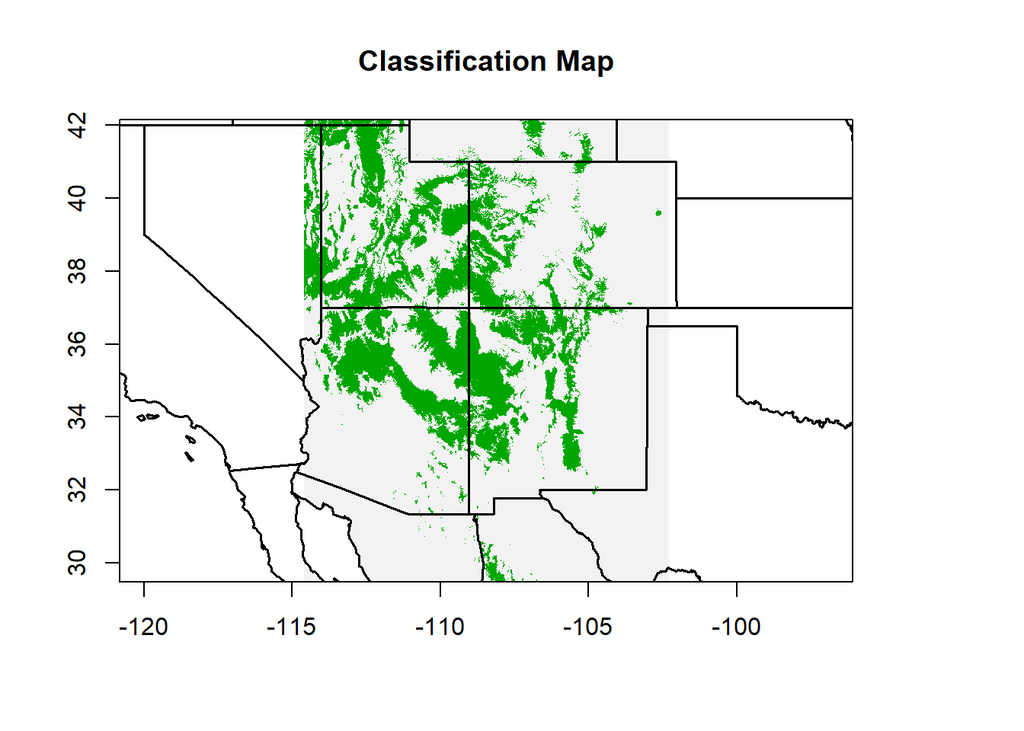

```r
#Classification Map#
plot(pers.class, legend = F,
     axes = T,
     main = "Classification Map") # plot classification map
plot(st_geometry(states),
     add = T,
     lwd = 1.5) # add state boundaries
```

## Question #6

- Save your data as R objects:
  - Accuracy metrics as a dataframe;
  - Classification threshold as a stand–alone scalar
  - Both prediction maps as **`.img`** format
- Save these R objects in a **`.RData`** file

These data will be used again in Module 10, Ensemble Models.

```r
setwd('C:/Users/14842/Documents/SDHM/sdhmR-V2022.1/SDHM_Reed/ex8')
```

[output not shown]

```r
save.image(pers.class,
           pers.prob,
           file = 'C:/Users/14842/Documents/SDHM/sdhmR-V2022.1/SDHM_Reed/ex8')
```

[output not shown]

```r
save(cut,
     mods.acc,
     pers.class,
     pers.prob,
     file = 'ex8.RData')
save.image()
```